# Project 2: Investigate the Kaggle European Soccer Database

Yu Tao 12/14/2020

- Introduction
- Data Wrangling
- Exploratory Data Analysis
- Conclusions

## Introduction

The **European Soccer Database** was analyzed to answer the following questions:

- What are the distributions of players age, height and weight?
- What teams improved the most over the time period?
- Which players had the most penalties?
- What team attributes lead to the most victories?
- What are the correlations between players attributes?
- What is the home team advantage in a soccer match?
- What are the best teams over the time period?
- Who are the best players over the time period?
- Who are the players that improved most over the time period?

The European Soccer Database can be downloaded from **Kaggle** via the following link: https://www.kaggle.com/hugomathien/soccer. This database contains data for different soccer matches, players, and teams from several European countries from 2008 to 2016. There are 7 tables included: **Country, League, Match, Player, Player_Attributes, Team, Team_Attributes.**

The soccer database is stored in a SQLite database. To begin with, I will need to first import all the necessary Python libraries for data wrangling and analysis, including **sqlite3, numpy, pandas, matplotlib, seaborn**.

```python
# first import all the libraries needed
import sqlite3 # to read the database
import numpy as np
import pandas as pd
import matplotlib.pyplot as plt
import seaborn as sns
%matplotlib inline

from sklearn.linear_model import LinearRegression

import warnings
warnings.filterwarnings('ignore')
```

## Data Wrangling

### General Properties

In the code cell below, I first used the **sqlite3** module to connect to the soccer database file (which is downloaded in the same directory as this Jupyter notebook). Then I used the **read_sql()** method in pandas to query each of the tables in the soccer database into 7 separate dataframes.

```python
# make separate dataframes for different tables in the soccer database.
soccer = sqlite3.connect('database.sqlite')

df_country = pd.read_sql('SELECT * FROM Country', soccer)
df_league = pd.read_sql('SELECT * FROM League', soccer)
df_match = pd.read_sql('SELECT * FROM Match', soccer)
df_player = pd.read_sql('SELECT * FROM Player', soccer)
df_player_attributes = pd.read_sql('SELECT * FROM Player_Attributes', soccer)
df_team = pd.read_sql('SELECT * FROM Team', soccer)
df_team_attributes = pd.read_sql('SELECT * FROM Team_Attributes', soccer)
```

In order to check the general properties of each dataframe, I will use **shape(), head() and info()** methods, respectively. If the row/column number is not too large for a dataframe, I wiil print the whole table.

```python
df_country.shape
```

```
(11, 2)
```

```python
# in the country dataframe, we have 11 countries with their id.
df_country
```

|  | id | name |
| --- | --- | --- |
| 0 | 1 | Belgium |
| 1 | 1729 | England |
| 2 | 4769 | France |
| 3 | 7809 | Germany |
| 4 | 10257 | Italy |
| 5 | 13274 | Netherlands |
| 6 | 15722 | Poland |
| 7 | 17642 | Portugal |
| 8 | 19694 | Scotland |
| 9 | 21518 | Spain |
| 10 | 24558 | Switzerland |

```python
df_country.info()
```

```
<class 'pandas.core.frame.DataFrame'>
RangeIndex: 11 entries, 0 to 10
Data columns (total 2 columns):
id      11 non-null int64
name    11 non-null object
dtypes: int64(1), object(1)
memory usage: 256.0+ bytes
```

```python
df_league.shape
```

```
(11, 3)
```

```python
# in the league dataframe, we have leagure names with the associated id and country_id.
# the id numbers used for the league are actually the same as the country id
df_league
```

|  | id | country_id | name |
| --- | --- | --- | --- |
| 0 | 1 | 1 | Belgium Jupiler League |
| 1 | 1729 | 1729 | England Premier League |
| 2 | 4769 | 4769 | France Ligue 1 |
| 3 | 7809 | 7809 | Germany 1. Bundesliga |
| 4 | 10257 | 10257 | Italy Serie A |
| 5 | 13274 | 13274 | Netherlands Eredivisie |
| 6 | 15722 | 15722 | Poland Ekstraklasa |
| 7 | 17642 | 17642 | Portugal Liga ZON Sagres |
| 8 | 19694 | 19694 | Scotland Premier League |
| 9 | 21518 | 21518 | Spain LIGA BBVA |
| 10 | 24558 | 24558 | Switzerland Super League |

```python
df_league.info()
```

```
<class 'pandas.core.frame.DataFrame'>
RangeIndex: 11 entries, 0 to 10
Data columns (total 3 columns):
id            11 non-null int64
country_id    11 non-null int64
name          11 non-null object
dtypes: int64(2), object(1)
memory usage: 344.0+ bytes
```

```python
df_match.shape
```

```
(25979, 115)
```

```python
# I printed the first five rows for the match dataframe, and there are 115 columns for each row.
# we can use the country_id and league_id columns to make connections between the match, country and league dataframes
df_match.head()
```

|  | id | country_id | league_id | season | stage | date | match_api_id | home_team_api_id | away_team_api_id | home_team_goal | ... | SJA | VCH | VCD | VCA | GBH | GBD | GBA | BSH | BSD | BSA |
| --- | --- | --- | --- | --- | --- | --- | --- | --- | --- | --- | --- | --- | --- | --- | --- | --- | --- | --- | --- | --- | --- |
| 0 | 1 | 1 | 1 | 2008/2009 | 1 | 2008-08-17 00:00:00 | 492473 | 9987 | 9993 | 1 | ... | 4.00 | 1.65 | 3.40 | 4.50 | 1.78 | 3.25 | 4.00 | 1.73 | 3.40 | 4.20 |
| 1 | 2 | 1 | 1 | 2008/2009 | 1 | 2008-08-16 00:00:00 | 492474 | 10000 | 9994 | 0 | ... | 3.80 | 2.00 | 3.25 | 3.25 | 1.85 | 3.25 | 3.75 | 1.91 | 3.25 | 3.60 |
| 2 | 3 | 1 | 1 | 2008/2009 | 1 | 2008-08-16 00:00:00 | 492475 | 9984 | 8635 | 0 | ... | 2.50 | 2.35 | 3.25 | 2.65 | 2.50 | 3.20 | 2.50 | 2.30 | 3.20 | 2.75 |
| 3 | 4 | 1 | 1 | 2008/2009 | 1 | 2008-08-17 00:00:00 | 492476 | 9991 | 9998 | 5 | ... | 7.50 | 1.45 | 3.75 | 6.50 | 1.50 | 3.75 | 5.50 | 1.44 | 3.75 | 6.50 |
| 4 | 5 | 1 | 1 | 2008/2009 | 1 | 2008-08-16 00:00:00 | 492477 | 7947 | 9985 | 1 | ... | 1.73 | 4.50 | 3.40 | 1.65 | 4.50 | 3.50 | 1.65 | 4.75 | 3.30 | 1.67 |

5 rows × 115 columns

```python
df_match.info()
```

```
<class 'pandas.core.frame.DataFrame'>
RangeIndex: 25979 entries, 0 to 25978
Columns: 115 entries, id to BSA
dtypes: float64(96), int64(9), object(10)
memory usage: 22.8+ MB
```

Since the match dataframe contains a large number of entries **(25979 rows, 115 columns)**, I decided to check for any missing values in this dataframe. Run the code below, I can see lots of missing values.

```python
# there are missing values except for the first 11 columns
df_match.isnull().sum()
```

```
id                      0
country_id              0
league_id               0
season                  0
stage                   0
date                    0
match_api_id            0
home_team_api_id        0
away_team_api_id        0
home_team_goal          0
away_team_goal          0
home_player_X1       1821
home_player_X2       1821
home_player_X3       1832
home_player_X4       1832
home_player_X5       1832
home_player_X6       1832
home_player_X7       1832
home_player_X8       1832
home_player_X9       1832
home_player_X10      1832
home_player_X11      1832
away_player_X1       1832
away_player_X2       1832
away_player_X3       1832
away_player_X4       1832
away_player_X5       1832
away_player_X6       1832
away_player_X7       1832
away_player_X8       1832
                    ...
B365H                3387
B365D                3387
B365A                3387
BWH                  3404
BWD                  3404
BWA                  3404
IWH                  3459
IWD                  3459
IWA                  3459
LBH                  3423
LBD                  3423
LBA                  3423
PSH                 14811
PSD                 14811
PSA                 14811
WHH                  3408
WHD                  3408
WHA                  3408
SJH                  8882
SJD                  8882
SJA                  8882
VCH                  3411
VCD                  3411
VCA                  3411
GBH                 11817
GBD                 11817
GBA                 11817
BSH                 11818
BSD                 11818
BSA                 11818
Length: 115, dtype: int64
```

To see if a match is duplicated recorded in the match dataframe, I used the **duplicated()** method in pandas. After running the code cell below, it indicated no duplicate matches, therefore, we don't need to remove any rows from the match dataframe for duplication.

```python
# no duplicate matches
df_match.duplicated().sum()
```

```
0
```

```python
df_player.shape
```

```
(11060, 7)
```

```python
# from the first five rows of the player dataframe, we see it contains the player's basic infomation and associated ids
df_player.head()
```

|  | id | player_api_id | player_name | player_fifa_api_id | birthday | height | weight |
| --- | --- | --- | --- | --- | --- | --- | --- |
| 0 | 1 | 505942 | Aaron Appindangoye | 218353 | 1992-02-29 00:00:00 | 182.88 | 187 |
| 1 | 2 | 155782 | Aaron Cresswell | 189615 | 1989-12-15 00:00:00 | 170.18 | 146 |
| 2 | 3 | 162549 | Aaron Doran | 186170 | 1991-05-13 00:00:00 | 170.18 | 163 |
| 3 | 4 | 30572 | Aaron Galindo | 140161 | 1982-05-08 00:00:00 | 182.88 | 198 |
| 4 | 5 | 23780 | Aaron Hughes | 17725 | 1979-11-08 00:00:00 | 182.88 | 154 |

```python
# there are no missing values in the player dataframe
df_player.info()
```

```
<class 'pandas.core.frame.DataFrame'>
RangeIndex: 11060 entries, 0 to 11059
Data columns (total 7 columns):
id                    11060 non-null int64
player_api_id         11060 non-null int64
player_name           11060 non-null object
player_fifa_api_id    11060 non-null int64
birthday              11060 non-null object
height                11060 non-null float64
weight                11060 non-null int64
dtypes: float64(1), int64(4), object(2)
memory usage: 604.9+ KB
```

```python
# there are no duplicates in the player dataframe as well
df_player.duplicated().sum()
```

```
0
```

```python
df_player_attributes.shape
```

```
(183978, 42)
```

```python
# from the player attributes dataframe, we can make connections to the player dataframe by player_api_id/player_fifa_api_id
df_player_attributes.head()
```

|  | id | player_fifa_api_id | player_api_id | date | overall_rating | potential | preferred_foot | attacking_work_rate | defensive_work_rate | crossing | ... | vision | penalties | marking | standing_tackle | sliding_tackle | gk_diving | gk_handling | gk_kicking | gk_positioning | gk_reflexes |
| --- | --- | --- | --- | --- | --- | --- | --- | --- | --- | --- | --- | --- | --- | --- | --- | --- | --- | --- | --- | --- | --- |
| 0 | 1 | 218353 | 505942 | 2016-02-18 00:00:00 | 67.0 | 71.0 | right | medium | medium | 49.0 | ... | 54.0 | 48.0 | 65.0 | 69.0 | 69.0 | 6.0 | 11.0 | 10.0 | 8.0 | 8.0 |
| 1 | 2 | 218353 | 505942 | 2015-11-19 00:00:00 | 67.0 | 71.0 | right | medium | medium | 49.0 | ... | 54.0 | 48.0 | 65.0 | 69.0 | 69.0 | 6.0 | 11.0 | 10.0 | 8.0 | 8.0 |
| 2 | 3 | 218353 | 505942 | 2015-09-21 00:00:00 | 62.0 | 66.0 | right | medium | medium | 49.0 | ... | 54.0 | 48.0 | 65.0 | 66.0 | 69.0 | 6.0 | 11.0 | 10.0 | 8.0 | 8.0 |
| 3 | 4 | 218353 | 505942 | 2015-03-20 00:00:00 | 61.0 | 65.0 | right | medium | medium | 48.0 | ... | 53.0 | 47.0 | 62.0 | 63.0 | 66.0 | 5.0 | 10.0 | 9.0 | 7.0 | 7.0 |
| 4 | 5 | 218353 | 505942 | 2007-02-22 00:00:00 | 61.0 | 65.0 | right | medium | medium | 48.0 | ... | 53.0 | 47.0 | 62.0 | 63.0 | 66.0 | 5.0 | 10.0 | 9.0 | 7.0 | 7.0 |

5 rows × 42 columns

```python
# there are missing values in all columns except the first four: id, player_fifa_api_id, player_api_id and date
df_player_attributes.info()
```

```
<class 'pandas.core.frame.DataFrame'>
RangeIndex: 183978 entries, 0 to 183977
Data columns (total 42 columns):
id                     183978 non-null int64
player_fifa_api_id     183978 non-null int64
player_api_id          183978 non-null int64
date                   183978 non-null object
overall_rating         183142 non-null float64
potential              183142 non-null float64
preferred_foot         183142 non-null object
attacking_work_rate    180748 non-null object
defensive_work_rate    183142 non-null object
crossing               183142 non-null float64
finishing              183142 non-null float64
heading_accuracy       183142 non-null float64
short_passing          183142 non-null float64
volleys                181265 non-null float64
dribbling              183142 non-null float64
curve                  181265 non-null float64
free_kick_accuracy     183142 non-null float64
long_passing           183142 non-null float64
ball_control           183142 non-null float64
acceleration           183142 non-null float64
sprint_speed           183142 non-null float64
agility                181265 non-null float64
reactions              183142 non-null float64
balance                181265 non-null float64
shot_power             183142 non-null float64
jumping                181265 non-null float64
stamina                183142 non-null float64
strength               183142 non-null float64
long_shots             183142 non-null float64
aggression             183142 non-null float64
interceptions          183142 non-null float64
positioning            183142 non-null float64
vision                 181265 non-null float64
penalties              183142 non-null float64
marking                183142 non-null float64
standing_tackle        183142 non-null float64
sliding_tackle         181265 non-null float64
gk_diving              183142 non-null float64
gk_handling            183142 non-null float64
gk_kicking             183142 non-null float64
gk_positioning         183142 non-null float64
gk_reflexes            183142 non-null float64
dtypes: float64(35), int64(3), object(4)
memory usage: 59.0+ MB
```

```python
# there are no duplicates in the player attributes dataframe
df_player_attributes.duplicated().sum()
```

```
0
```

```python
df_team.shape
```

```
(299, 5)
```

```python
# in the team dataframe, we have the long and short names of a team and its diferent ids
df_team.head()
```

|  | id | team_api_id | team_fifa_api_id | team_long_name | team_short_name |
| --- | --- | --- | --- | --- | --- |
| 0 | 1 | 9987 | 673.0 | KRC Genk | GEN |
| 1 | 2 | 9993 | 675.0 | Beerschot AC | BAC |
| 2 | 3 | 10000 | 15005.0 | SV Zulte-Waregem | ZUL |
| 3 | 4 | 9994 | 2007.0 | Sporting Lokeren | LOK |
| 4 | 5 | 9984 | 1750.0 | KSV Cercle Brugge | CEB |

```python
# we have 11 missing values for the team_fifa_api_id
df_team.info()
```

```
<class 'pandas.core.frame.DataFrame'>
RangeIndex: 299 entries, 0 to 298
Data columns (total 5 columns):
id                  299 non-null int64
team_api_id         299 non-null int64
team_fifa_api_id    288 non-null float64
team_long_name      299 non-null object
team_short_name     299 non-null object
dtypes: float64(1), int64(2), object(2)
memory usage: 11.8+ KB
```

```python
# no duplicate teams in the team dataframe
df_team.duplicated().sum()
```

```
0
```

```python
df_team_attributes.shape
```

```
(1458, 25)
```

```python
# we can use the ids from the first three columns to connect with the team dataframe
df_team_attributes.head()
```

|  | id | team_fifa_api_id | team_api_id | date | buildUpPlaySpeed | buildUpPlaySpeedClass | buildUpPlayDribbling | buildUpPlayDribblingClass | buildUpPlayPassing | buildUpPlayPassingClass | ... | chanceCreationShooting | chanceCreationShootingClass | chanceCreationPositioningClass | defencePressure | defencePressureClass | defenceAggression | defenceAggressionClass | defenceTeamWidth | defenceTeamWidthClass | defenceDefenderLineClass |
| --- | --- | --- | --- | --- | --- | --- | --- | --- | --- | --- | --- | --- | --- | --- | --- | --- | --- | --- | --- | --- | --- |
| 0 | 1 | 434 | 9930 | 2010-02-22 00:00:00 | 60 | Balanced | NaN | Little | 50 | Mixed | ... | 55 | Normal | Organised | 50 | Medium | 55 | Press | 45 | Normal | Cover |
| 1 | 2 | 434 | 9930 | 2014-09-19 00:00:00 | 52 | Balanced | 48.0 | Normal | 56 | Mixed | ... | 64 | Normal | Organised | 47 | Medium | 44 | Press | 54 | Normal | Cover |
| 2 | 3 | 434 | 9930 | 2015-09-10 00:00:00 | 47 | Balanced | 41.0 | Normal | 54 | Mixed | ... | 64 | Normal | Organised | 47 | Medium | 44 | Press | 54 | Normal | Cover |
| 3 | 4 | 77 | 8485 | 2010-02-22 00:00:00 | 70 | Fast | NaN | Little | 70 | Long | ... | 70 | Lots | Organised | 60 | Medium | 70 | Double | 70 | Wide | Cover |
| 4 | 5 | 77 | 8485 | 2011-02-22 00:00:00 | 47 | Balanced | NaN | Little | 52 | Mixed | ... | 52 | Normal | Organised | 47 | Medium | 47 | Press | 52 | Normal | Cover |

5 rows × 25 columns

```python
# there are many missing values in buildUpPlayDribbling column
df_team_attributes.info()
```

```
<class 'pandas.core.frame.DataFrame'>
RangeIndex: 1458 entries, 0 to 1457
Data columns (total 25 columns):
id                                1458 non-null int64
team_fifa_api_id                  1458 non-null int64
team_api_id                       1458 non-null int64
date                              1458 non-null object
buildUpPlaySpeed                  1458 non-null int64
buildUpPlaySpeedClass             1458 non-null object
buildUpPlayDribbling              489 non-null float64
buildUpPlayDribblingClass         1458 non-null object
buildUpPlayPassing                1458 non-null int64
buildUpPlayPassingClass           1458 non-null object
buildUpPlayPositioningClass       1458 non-null object
chanceCreationPassing             1458 non-null int64
chanceCreationPassingClass        1458 non-null object
chanceCreationCrossing            1458 non-null int64
chanceCreationCrossingClass       1458 non-null object
chanceCreationShooting            1458 non-null int64
chanceCreationShootingClass       1458 non-null object
chanceCreationPositioningClass    1458 non-null object
defencePressure                   1458 non-null int64
defencePressureClass              1458 non-null object
defenceAggression                 1458 non-null int64
defenceAggressionClass            1458 non-null object
defenceTeamWidth                  1458 non-null int64
defenceTeamWidthClass             1458 non-null object
defenceDefenderLineClass          1458 non-null object
dtypes: float64(1), int64(11), object(13)
memory usage: 284.8+ KB
```

```python
# duplication row check
df_team_attributes.duplicated().sum()
```

```
0
```

### Data Cleaning

In this section I will show the following data cleaning procedures.

- **Trim columns in the match dataframe that we don't need for future analysis.**
- **Convert the data type in either the 'date' or 'birthday' column to datetime.**
- **Other data cleaning process shown at the beginning of each question.**

**Note: I also performed many other data cleaning procedures, such as merging multiple files together to answer specific question listed in the introduction section. For better context for the readers, I moved these procedures to the beginning of each question where you can find them.**

From the previous section, we found that there are 115 columns in the match dataframe, and many missing values are present except for the first 11 columns. When we analyze a certain match, we are mostly interested in getting the infomation such as: when the match was played, which two teams played against each other and what the result (how many goals scored by each team) of that match is. Therefore, I decided to keep the first 11 columns because (1): these columns contain the most important information about a match. (2) these columns don't have missing values, which is convenient for further analysis.

```python
# keeping the first 11 columns in the match dataframe, which is equivalent to dropping all columns with missing values
df_match.dropna(axis = 1, inplace = True)
```

```python
# check the cleaning is correct
df_match.head()
```

|  | id | country_id | league_id | season | stage | date | match_api_id | home_team_api_id | away_team_api_id | home_team_goal | away_team_goal |
| --- | --- | --- | --- | --- | --- | --- | --- | --- | --- | --- | --- |
| 0 | 1 | 1 | 1 | 2008/2009 | 1 | 2008-08-17 00:00:00 | 492473 | 9987 | 9993 | 1 | 1 |
| 1 | 2 | 1 | 1 | 2008/2009 | 1 | 2008-08-16 00:00:00 | 492474 | 10000 | 9994 | 0 | 0 |
| 2 | 3 | 1 | 1 | 2008/2009 | 1 | 2008-08-16 00:00:00 | 492475 | 9984 | 8635 | 0 | 3 |
| 3 | 4 | 1 | 1 | 2008/2009 | 1 | 2008-08-17 00:00:00 | 492476 | 9991 | 9998 | 5 | 0 |
| 4 | 5 | 1 | 1 | 2008/2009 | 1 | 2008-08-16 00:00:00 | 492477 | 7947 | 9985 | 1 | 3 |

For the date column, from previous run info() code cell, we know it has the type of 'object', therefore, we need to convert the date column type to 'datetime'. I will start with the match dataframe.

```python
# convert to datetime for date in match dataframe
df_match['date'] = pd.to_datetime(df_match['date'])
```

There are also 'date' or 'birthday' columns in other dataframes where we need to change the data type to datetime. These columns include the 'birthday' column in the player dataframe, the 'date' column in both the player_attributes and the team_attributes dataframes.

```python
# convert to datatime for other dataframes
df_player['birthday'] = pd.to_datetime(df_player['birthday'])
df_player_attributes['date'] = pd.to_datetime(df_player_attributes['date'])
df_team_attributes['date'] = pd.to_datetime(df_team_attributes['date'])

# check the type of date and birthday cloumns
df_match['date'].dtypes, df_player['birthday'].dtypes, df_player_attributes['date'].dtypes, df_team_attributes['date'].dtypes
```

```
(dtype('<M8[ns]'), dtype('<M8[ns]'), dtype('<M8[ns]'), dtype('<M8[ns]'))
```

## Exploratory Data Analysis

### Research Question 0: Players' age, height & weight distributions

To look at the distributions of the players' age (birthyear), height and weight, we can plot their respective histograms. Before that, we need to first extract players' birthyears from the 'birthday' column in the player dataframe.

```python
# extract birthyear from birthday and obtain basic statistics from birthyear, height and weight columns
df_player['birthyear'] = df_player['birthday'].apply(lambda t: t.year)
df_player[['birthyear', 'height', 'weight']].describe()
```

|  | birthyear | height | weight |
| --- | --- | --- | --- |
| count | 11060.000000 | 11060.000000 | 11060.000000 |
| mean | 1986.642857 | 181.867445 | 168.380289 |
| std | 5.481362 | 6.369201 | 14.990217 |
| min | 1967.000000 | 157.480000 | 117.000000 |
| 25% | 1983.000000 | 177.800000 | 159.000000 |
| 50% | 1987.000000 | 182.880000 | 168.000000 |
| 75% | 1991.000000 | 185.420000 | 179.000000 |
| max | 1999.000000 | 208.280000 | 243.000000 |

```
array([[<matplotlib.axes._subplots.AxesSubplot object at 0x00000207CCD43390>,
      dtype=object)
```

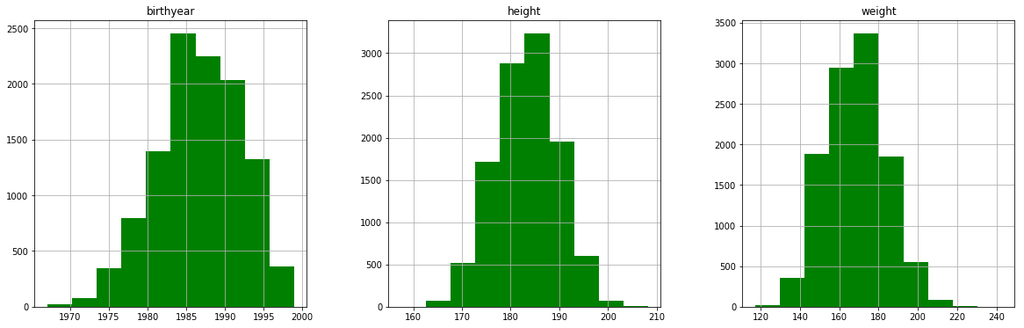

```python
# Visualize the distribution of each variables
df_player[['birthyear', 'height', 'weight']].hist(figsize = (20, 6), layout = (1, 3), color = 'g')
```

**Here are some conclusions for question 0:**

- **In terms of birthyear, the oldest player was born in 1967 and the youngest player was born in 1999. The average birthyear of a player is 1986, with most of the players (75%) born after 1983.**
- **In terms of players' height, the tallest player is 208.28cm and the shorest player is 157.48cm. The average height of a player is 181.87cm.**
- **In terms of players' weight, the heaviest player is 243.00lb and the lightest player is 117.00lb. The average weight of a player is 168.38lb.**
- **The birthyear, height and weight are approximately normally distributed. From the birtyear distribution, one can also see that younger players are more favored in soccer games.**

### Research Question 1: What teams improved the most over the time period?

There are many evaluation matrices we can use to measure the improvements of a team, for this question, I decide to investigate the average goals scored by each team in their home and away games, and compare which teams have the most increase in goals from 2008/2009 season to 2015/2016 season.

To answer this question, I realize the most important dataframes are **the team and the match dataframes**, where we can conncet and inspect the performance of a team in every single game they have played. First, we will need to do some data wrangling with these two dataframes.

```python
# first make a copy of the match dataframe, I will call it match_copy
df_match_copy = df_match.copy()

# merge team and match dataframes, first for the home team
df_match_copy = df_match_copy.merge(df_team, left_on='home_team_api_id', right_on='team_api_id', how='inner')
df_match_copy.rename(columns={'team_long_name': 'home_team_name'}, inplace=True)
df_match_copy.drop(columns=['home_team_api_id', 'team_api_id'], axis=1, inplace=True)

# merge team and match dataframes, next for the away team
df_match_copy = df_match_copy.merge(df_team, left_on='away_team_api_id', right_on='team_api_id', how='left')
df_match_copy.rename(columns={'team_long_name': 'away_team_name'}, inplace=True)
df_match_copy.drop(columns=['away_team_api_id', 'team_api_id'], axis=1, inplace=True)

# print the first five rows of the new match_copy dataframe
df_match_copy.head()
```

|  | id_x | country_id | league_id | season | stage | date | match_api_id | home_team_goal | away_team_goal | id_y | team_fifa_api_id_x | home_team_name | team_short_name_x | id | team_fifa_api_id_y | away_team_name | team_short_name_y |
| --- | --- | --- | --- | --- | --- | --- | --- | --- | --- | --- | --- | --- | --- | --- | --- | --- | --- |
| 0 | 1 | 1 | 1 | 2008/2009 | 1 | 2008-08-17 | 492473 | 1 | 1 | 1 | 673.0 | KRC Genk | GEN | 2 | 675.0 | Beerschot AC | BAC |
| 1 | 29 | 1 | 1 | 2008/2009 | 12 | 2008-11-15 | 492583 | 1 | 1 | 1 | 673.0 | KRC Genk | GEN | 13 | 546.0 | KSV Roeselare | ROS |
| 2 | 47 | 1 | 1 | 2008/2009 | 14 | 2008-11-29 | 492651 | 3 | 2 | 1 | 673.0 | KRC Genk | GEN | 5 | 1750.0 | KSV Cercle Brugge | CEB |
| 3 | 65 | 1 | 1 | 2008/2009 | 16 | 2008-12-13 | 492713 | 1 | 0 | 1 | 673.0 | KRC Genk | GEN | 18 | 670.0 | Sporting Charleroi | CHA |
| 4 | 94 | 1 | 1 | 2008/2009 | 19 | 2009-01-24 | 492805 | 2 | 0 | 1 | 673.0 | KRC Genk | GEN | 8 | 1747.0 | RAEC Mons | MON |

```python
# clean the match_copy dataframe, drop columns we don't need and rename columns
df_match_copy.drop(['stage', 'id_y', 'team_fifa_api_id_x', 'team_short_name_x', 'id', 'team_fifa_api_id_y', 'team_short_name_y'], axis=1, inplace=True)
df_match_copy.rename(columns = {'id_x': 'id'}, inplace=True)
df_match_copy.head()
```

|  | id | country_id | league_id | season | date | match_api_id | home_team_goal | away_team_goal | home_team_name | away_team_name |
| --- | --- | --- | --- | --- | --- | --- | --- | --- | --- | --- |
| 0 | 1 | 1 | 1 | 2008/2009 | 2008-08-17 | 492473 | 1 | 1 | KRC Genk | Beerschot AC |
| 1 | 29 | 1 | 1 | 2008/2009 | 2008-11-15 | 492583 | 1 | 1 | KRC Genk | KSV Roeselare |
| 2 | 47 | 1 | 1 | 2008/2009 | 2008-11-29 | 492651 | 3 | 2 | KRC Genk | KSV Cercle Brugge |
| 3 | 65 | 1 | 1 | 2008/2009 | 2008-12-13 | 492713 | 1 | 0 | KRC Genk | Sporting Charleroi |
| 4 | 94 | 1 | 1 | 2008/2009 | 2009-01-24 | 492805 | 2 | 0 | KRC Genk | RAEC Mons |

After the data clean process above, I generated a new dataframe match_copy, which contains the home/away team name and goal information. The next steps are:

- query two subsets from match_copy dataframe, one includes matches only from 2008/2009 season, the other for 2015/2016 season.
- for each subset, grouy by home/away team names and find their average goals scored.
- compare the results from both seasons, calculate the difference for each team and list top 10 teams with the most increase in goal scored.

```python
# sub dataframes from match_copy for single season data (2008/2009 and 2015/2016)
df_match_2009 = df_match_copy.query('season == "2008/2009"')
df_match_2016 = df_match_copy.query('season == "2015/2016"')

# group by home/away team names and find the average goal scored by each home/away team
df_match_2009_home = df_match_2009.groupby(['home_team_name'])['home_team_goal'].mean()
df_match_2009_away = df_match_2009.groupby(['away_team_name'])['away_team_goal'].mean()

df_match_2016_home = df_match_2016.groupby(['home_team_name'])['home_team_goal'].mean()
df_match_2016_away = df_match_2016.groupby(['away_team_name'])['away_team_goal'].mean()

# the improvement is defined as the increase in goal scored in home/away games from 2008 to 2016
df_improvement_home = df_match_2016_home - df_match_2009_home
df_improvement_away = df_match_2016_away - df_match_2009_away
```

```python
# sort home improvements by drcreasing order and find the top 10 most improved home teams (drop NaN values in case)
df_improvement_home.dropna(inplace=True)
df_top10_home_goal = df_improvement_home.sort_values(ascending=False)[:10]
sorted_index_1 = df_top10_home_goal.index

# sort away improvements by drcreasing order and find the top 10 most improved away teams (drop NaN values in case)
df_improvement_away.dropna(inplace=True)
df_top10_away_goal = df_improvement_away.sort_values(ascending=False)[:10]
sorted_index_2 = df_top10_away_goal.index
```

We have two new dataframes, **top10_home_goal** and **top10_away_goal** that include the team names and their respective increase in average home/away goals over the time period. We will visualize them use bar plots below.

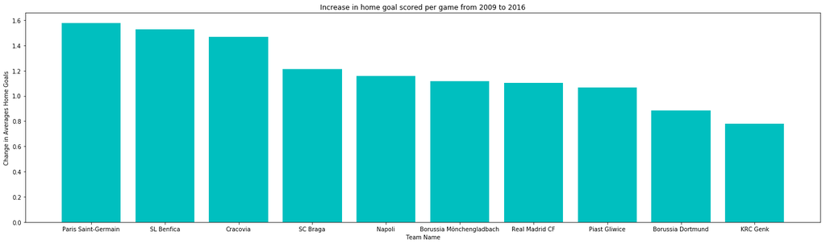

```python
# improvement in goal scored at home per game
fig, ax = plt.subplots(figsize=(20, 6))

plt.bar(range(0,len(sorted_index_1)), df_top10_home_goal, color = 'c')

ax.set_title('Increase in home goal scored per game from 2009 to 2016')

plt.ylabel("Change in Averages Home Goals")
ax.set_xlabel('Team Name')
ax.set_xticks(range(0,len(sorted_index_1)))
ax.set_xticklabels(sorted_index_1)

plt.tight_layout()
```

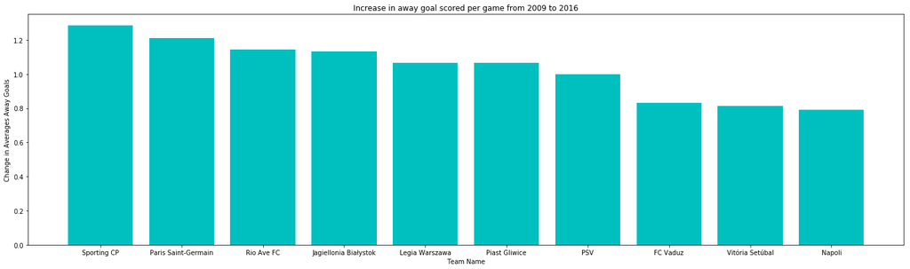

```python
# improvement in goal scored at away per game
fig, ax = plt.subplots(figsize=(20, 6))

plt.bar(range(0,len(sorted_index_2)), df_top10_away_goal, color = 'c')

ax.set_title('Increase in away goal scored per game from 2009 to 2016')

plt.ylabel("Change in Averages Away Goals")
ax.set_xlabel('Team Name')
ax.set_xticks(range(0,len(sorted_index_2)))
ax.set_xticklabels(sorted_index_2)

plt.tight_layout()
```

**Here are some clnclusions for question 1:**

- **In terms of home goal increase per game, Paris Saint-Germain, SL Benfica and Cracovia are the teams that improved most.**
- **In terms of away goal increase per game, Sporting CP, Paris Saint-Germain and Rio Ave FC are the teams that improved most.**
- **Overall, Paris Saint-Germain is the team that improved the most over the time period, with home goals increased by ~1.6 per game and away goals increased by ~1.2 per game.**

### Research Question 2: Which players had the most penalties?

To answer this question, we need to compare between players and check their corresponding penalty attributes, therefore, we need two dataframes: **player and player_attributes**. First, I made a copy of the player attributes dataframe and merged it with the player dataframe.

```python
# make a copy of the player attributes dataframe
df_player_attributes_copy = df_player_attributes.copy()

# merge player and player_attributes dataframes
df_player_attributes_copy = df_player_attributes_copy.merge(df_player, left_on='player_api_id', right_on='player_api_id', how='inner')
df_player_attributes_copy.head()
```

|  | id_x | player_fifa_api_id_x | player_api_id | date | overall_rating | potential | preferred_foot | attacking_work_rate | defensive_work_rate | crossing | ... | gk_kicking | gk_positioning | gk_reflexes | id_y | player_name | player_fifa_api_id_y | birthday | height | weight | birthyear |
| --- | --- | --- | --- | --- | --- | --- | --- | --- | --- | --- | --- | --- | --- | --- | --- | --- | --- | --- | --- | --- | --- |
| 0 | 1 | 218353 | 505942 | 2016-02-18 | 67.0 | 71.0 | right | medium | medium | 49.0 | ... | 10.0 | 8.0 | 8.0 | 1 | Aaron Appindangoye | 218353 | 1992-02-29 | 182.88 | 187 | 1992 |
| 1 | 2 | 218353 | 505942 | 2015-11-19 | 67.0 | 71.0 | right | medium | medium | 49.0 | ... | 10.0 | 8.0 | 8.0 | 1 | Aaron Appindangoye | 218353 | 1992-02-29 | 182.88 | 187 | 1992 |
| 2 | 3 | 218353 | 505942 | 2015-09-21 | 62.0 | 66.0 | right | medium | medium | 49.0 | ... | 10.0 | 8.0 | 8.0 | 1 | Aaron Appindangoye | 218353 | 1992-02-29 | 182.88 | 187 | 1992 |
| 3 | 4 | 218353 | 505942 | 2015-03-20 | 61.0 | 65.0 | right | medium | medium | 48.0 | ... | 9.0 | 7.0 | 7.0 | 1 | Aaron Appindangoye | 218353 | 1992-02-29 | 182.88 | 187 | 1992 |
| 4 | 5 | 218353 | 505942 | 2007-02-22 | 61.0 | 65.0 | right | medium | medium | 48.0 | ... | 9.0 | 7.0 | 7.0 | 1 | Aaron Appindangoye | 218353 | 1992-02-29 | 182.88 | 187 | 1992 |

5 rows × 49 columns

```python
# drop columns we don't need
df_player_attributes_copy.drop(columns=['id_x', 'player_fifa_api_id_x', 'id_y', 'player_fifa_api_id_y'], inplace=True)
df_player_attributes_copy.head()
```

|  | player_api_id | date | overall_rating | potential | preferred_foot | attacking_work_rate | defensive_work_rate | crossing | finishing | heading_accuracy | ... | gk_diving | gk_handling | gk_kicking | gk_positioning | gk_reflexes | player_name | birthday | height | weight | birthyear |
| --- | --- | --- | --- | --- | --- | --- | --- | --- | --- | --- | --- | --- | --- | --- | --- | --- | --- | --- | --- | --- | --- |
| 0 | 505942 | 2016-02-18 | 67.0 | 71.0 | right | medium | medium | 49.0 | 44.0 | 71.0 | ... | 6.0 | 11.0 | 10.0 | 8.0 | 8.0 | Aaron Appindangoye | 1992-02-29 | 182.88 | 187 | 1992 |
| 1 | 505942 | 2015-11-19 | 67.0 | 71.0 | right | medium | medium | 49.0 | 44.0 | 71.0 | ... | 6.0 | 11.0 | 10.0 | 8.0 | 8.0 | Aaron Appindangoye | 1992-02-29 | 182.88 | 187 | 1992 |
| 2 | 505942 | 2015-09-21 | 62.0 | 66.0 | right | medium | medium | 49.0 | 44.0 | 71.0 | ... | 6.0 | 11.0 | 10.0 | 8.0 | 8.0 | Aaron Appindangoye | 1992-02-29 | 182.88 | 187 | 1992 |
| 3 | 505942 | 2015-03-20 | 61.0 | 65.0 | right | medium | medium | 48.0 | 43.0 | 70.0 | ... | 5.0 | 10.0 | 9.0 | 7.0 | 7.0 | Aaron Appindangoye | 1992-02-29 | 182.88 | 187 | 1992 |
| 4 | 505942 | 2007-02-22 | 61.0 | 65.0 | right | medium | medium | 48.0 | 43.0 | 70.0 | ... | 5.0 | 10.0 | 9.0 | 7.0 | 7.0 | Aaron Appindangoye | 1992-02-29 | 182.88 | 187 | 1992 |

5 rows × 45 columns

In this new dataframe **player_attributes_copy**, the penalty information is now associated with the players' names, we can then group by players' name and api_id (in case two or more players have the same name), sum over their penalty attributes and sort by decending order.

```python
# groupby player_api_id & player_name in case 2 or more players have the same name, find top 10 players with most penalties
df_penalty = df_player_attributes_copy.groupby(['player_api_id', 'player_name'])['penalties'].sum().sort_values(ascending=False)[:10]
sorted_index = df_penalty.index
```

```python
# print out the top 10 players with the most penalties (saved in df_penalty)
df_penalty
```

```
player_api_id  player_name
41269          Alessio Cerci         4314.0
108808         Mario Balotelli       4120.0
41890          Claudio Marchisio     3984.0
26472          Michael Bradley       3813.0
25772          Zdravko Kuzmanovic    3799.0
30731          Andrea Pirlo          3791.0
27734          Antonio Di Natale     3767.0
30626          Thierry Henry         3712.0
40930          Adrien Silva          3682.0
47394          Adel Taarabt          3650.0
Name: penalties, dtype: float64
```

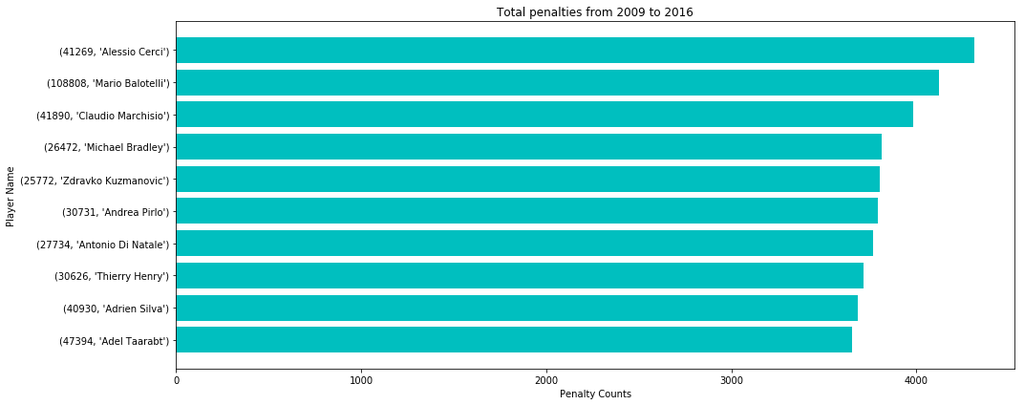

```python
# plot to visualize the players with most penalties
fig, ax = plt.subplots(figsize=(15, 6))

plt.barh(range(0,len(df_penalty)), df_penalty, color = 'c')

ax.set_title('Total penalties from 2009 to 2016')

plt.xlabel("Penalty Counts")
ax.set_ylabel('Player Name')
ax.set_yticks(range(0,len(sorted_index)))
ax.set_yticklabels(sorted_index)
ax.invert_yaxis()

plt.tight_layout()
```

**To answer question 2:**

- **Alessio Cerci (4314), Mario Balotelli (4120) and Claudio Marchisio (3984) are the players with most penalties.**

### Research Question 3: What team attributes lead to the most victories?

To answer this question, I decided to focus on the 2015/2016 season, and we are going to use the **match_copy, team and team attributes dataframes**. In general, there are two steps needed to be done:

- figure out which teams had the most victories in 2015/2016 season.
- analyze the team attributes of each successful team.

From question 1, we generated a dataframe called **match_copy**, which has the team and goal information from each match. Below cells utilized this dataframes and created new columns that store extra information of the winning teams of each match.

```python
# remind ourselves of what the match_copy dataframe looks like
df_match_copy.head()
```

|  | id | country_id | league_id | season | date | match_api_id | home_team_goal | away_team_goal | home_team_name | away_team_name |
| --- | --- | --- | --- | --- | --- | --- | --- | --- | --- | --- |
| 0 | 1 | 1 | 1 | 2008/2009 | 2008-08-17 | 492473 | 1 | 1 | KRC Genk | Beerschot AC |
| 1 | 29 | 1 | 1 | 2008/2009 | 2008-11-15 | 492583 | 1 | 1 | KRC Genk | KSV Roeselare |
| 2 | 47 | 1 | 1 | 2008/2009 | 2008-11-29 | 492651 | 3 | 2 | KRC Genk | KSV Cercle Brugge |
| 3 | 65 | 1 | 1 | 2008/2009 | 2008-12-13 | 492713 | 1 | 0 | KRC Genk | Sporting Charleroi |
| 4 | 94 | 1 | 1 | 2008/2009 | 2009-01-24 | 492805 | 2 | 0 | KRC Genk | RAEC Mons |

To add winner info to each match, I created a function that takes home/away team names and goals and outputs the winner's name (or 'Draw') by comparing the goal difference.

```python
# the winner function
def winner(column):
    home_goal, away_goal = column[0], column[1]
    home_team_name, away_team_name = column[2], column[3]

    if home_goal > away_goal:
        return home_team_name
    elif home_goal < away_goal:
        return away_team_name
    else:
        return 'Draw'

# create a new column called winner in the match_copy dataframe, which records the winner's name of each match
df_match_copy['winner'] = df_match_copy[['home_team_goal', 'away_team_goal', 'home_team_name', 'away_team_name']].apply(winner, axis=1)
```

```python
# query for the match data from 2015/2016 season only
df_last_season = df_match_copy.query('season == "2015/2016"')
```

```python
# group by the winners' names and count how many times they appear in 2015/16 season and sort by decending order
df_last_season_winners = df_last_season.groupby('winner')['id'].count().sort_values(ascending=False)
# find the top 10 winning teams in 2015/2016 season, which is saved in a dataframe called last_season_winners
# PS: the first entry is draw, so we start from index 1
df_last_season_winners[1:11]
```

```
winner
Paris Saint-Germain    30
Juventus               29
FC Barcelona           29
SL Benfica             29
FC Bayern Munich       28
Atlético Madrid        28
Real Madrid CF         28
Sporting CP            27
Celtic                 26
FC Basel               26
Name: id, dtype: int64
```

From the output box above, we can see a list of ten teams (**Paris Saint-Germain, Juventus, FC Barcelona, SL Benfica, FC Bayern Munich, Atlético Madrid, Real Madrid CF, Sporting CP, Celtic, FC Basel**) with most victories and the number of matches they have won in 2015/2016 season. Now, let's find their respective team attributes.

The next thing I will do is to merge the team and team attributes dataframe, stored in **team_attributes_all**, because in this way we can directly find a team's attributes by its team name.

```python
# merge team and team attributes dataframes
df_team_attributes_all = df_team_attributes.merge(df_team, left_on='team_api_id', right_on='team_api_id', how='inner')

# rename 2 columns
df_team_attributes_all.rename(columns={'id_x': 'id', 'team_fifa_api_id_x': 'team_fifa_api_id'}, inplace=True)
df_team_attributes_all.head()
```

|  | id | team_fifa_api_id | team_api_id | date | buildUpPlaySpeed | buildUpPlaySpeedClass | buildUpPlayDribbling | buildUpPlayDribblingClass | buildUpPlayPassing | buildUpPlayPassingClass | ... | defencePressureClass | defenceAggression | defenceAggressionClass | defenceTeamWidth | defenceTeamWidthClass | defenceDefenderLineClass | id_y | team_fifa_api_id_y | team_long_name | team_short_name |
| --- | --- | --- | --- | --- | --- | --- | --- | --- | --- | --- | --- | --- | --- | --- | --- | --- | --- | --- | --- | --- | --- |
| 0 | 1 | 434 | 9930 | 2010-02-22 | 60 | Balanced | NaN | Little | 50 | Mixed | ... | Medium | 55 | Press | 45 | Normal | Cover | 49119 | 434.0 | FC Aarau | AAR |
| 1 | 2 | 434 | 9930 | 2014-09-19 | 52 | Balanced | 48.0 | Normal | 56 | Mixed | ... | Medium | 44 | Press | 54 | Normal | Cover | 49119 | 434.0 | FC Aarau | AAR |
| 2 | 3 | 434 | 9930 | 2015-09-10 | 47 | Balanced | 41.0 | Normal | 54 | Mixed | ... | Medium | 44 | Press | 54 | Normal | Cover | 49119 | 434.0 | FC Aarau | AAR |
| 3 | 4 | 77 | 8485 | 2010-02-22 | 70 | Fast | NaN | Little | 70 | Long | ... | Medium | 70 | Double | 70 | Wide | Cover | 39393 | 77.0 | Aberdeen | ABE |
| 4 | 5 | 77 | 8485 | 2011-02-22 | 47 | Balanced | NaN | Little | 52 | Mixed | ... | Medium | 47 | Press | 52 | Normal | Cover | 39393 | 77.0 | Aberdeen | ABE |

5 rows × 29 columns

```python
# look at the basic info of the team_attributes_all dataframe
df_team_attributes_all.info()
```

```
<class 'pandas.core.frame.DataFrame'>
Int64Index: 1458 entries, 0 to 1457
Data columns (total 29 columns):
id                                1458 non-null int64
team_fifa_api_id                  1458 non-null int64
team_api_id                       1458 non-null int64
date                              1458 non-null datetime64[ns]
buildUpPlaySpeed                  1458 non-null int64
buildUpPlaySpeedClass             1458 non-null object
buildUpPlayDribbling              489 non-null float64
buildUpPlayDribblingClass         1458 non-null object
buildUpPlayPassing                1458 non-null int64
buildUpPlayPassingClass           1458 non-null object
buildUpPlayPositioningClass       1458 non-null object
chanceCreationPassing             1458 non-null int64
chanceCreationPassingClass        1458 non-null object
chanceCreationCrossing            1458 non-null int64
chanceCreationCrossingClass       1458 non-null object
chanceCreationShooting            1458 non-null int64
chanceCreationShootingClass       1458 non-null object
chanceCreationPositioningClass    1458 non-null object
defencePressure                   1458 non-null int64
defencePressureClass              1458 non-null object
defenceAggression                 1458 non-null int64
defenceAggressionClass            1458 non-null object
defenceTeamWidth                  1458 non-null int64
defenceTeamWidthClass             1458 non-null object
defenceDefenderLineClass          1458 non-null object
id_y                              1458 non-null int64
team_fifa_api_id_y                1458 non-null float64
team_long_name                    1458 non-null object
team_short_name                   1458 non-null object
dtypes: datetime64[ns](1), float64(2), int64(12), object(14)
memory usage: 341.7+ KB
```

```python
# generate a column from date that contains the year infomation
df_team_attributes_all['year'] = df_team_attributes_all['date'].dt.year
```

Below cell listed the columns that contain the team attributes we are interested in.

```python
columns = ['team_long_name', 'buildUpPlaySpeed', 'buildUpPlayDribbling', 'buildUpPlayPassing',\
           'chanceCreationPassing', 'chanceCreationCrossing', 'chanceCreationShooting',\
           'defencePressure', 'defenceAggression', 'defenceTeamWidth']
```

```python
# generate a winner list from our first step analysis from the match_copy dataframe
winner_list = df_last_season_winners[1:11].index
```

```python
# query the team_attributes_all dataframe for team attributes of the teams in our winning list,
# also only include years of either 2015 or 2016, and only columns we are interested in
best_team_attributes = df_team_attributes_all.query('(year == 2015 or year == 2016) and team_long_name in @winner_list')[columns]
```

```python
# print out the team attributes of the team with most victories
best_team_attributes
```

|  | team_long_name | buildUpPlaySpeed | buildUpPlayDribbling | buildUpPlayPassing | chanceCreationPassing | chanceCreationCrossing | chanceCreationShooting | defencePressure | defenceAggression | defenceTeamWidth |
| --- | --- | --- | --- | --- | --- | --- | --- | --- | --- | --- |
| 99 | Atlético Madrid | 57 | 50.0 | 50 | 61 | 62 | 49 | 49 | 42 | 52 |
| 123 | FC Barcelona | 36 | 35.0 | 51 | 36 | 49 | 56 | 61 | 65 | 65 |
| 135 | FC Basel | 61 | 63.0 | 46 | 66 | 66 | 54 | 47 | 58 | 53 |
| 147 | FC Bayern Munich | 45 | 24.0 | 28 | 37 | 31 | 22 | 72 | 53 | 59 |
| 165 | SL Benfica | 69 | 55.0 | 53 | 65 | 66 | 54 | 60 | 57 | 54 |
| 293 | Celtic | 54 | 49.0 | 53 | 51 | 51 | 62 | 58 | 55 | 56 |
| 629 | Juventus | 50 | 35.0 | 20 | 65 | 50 | 80 | 35 | 65 | 35 |
| 966 | Paris Saint-Germain | 49 | 47.0 | 34 | 62 | 61 | 35 | 57 | 53 | 56 |
| 1053 | Real Madrid CF | 50 | 57.0 | 46 | 61 | 41 | 63 | 52 | 60 | 63 |
| 1197 | Sporting CP | 57 | 65.0 | 56 | 42 | 50 | 55 | 60 | 60 | 54 |

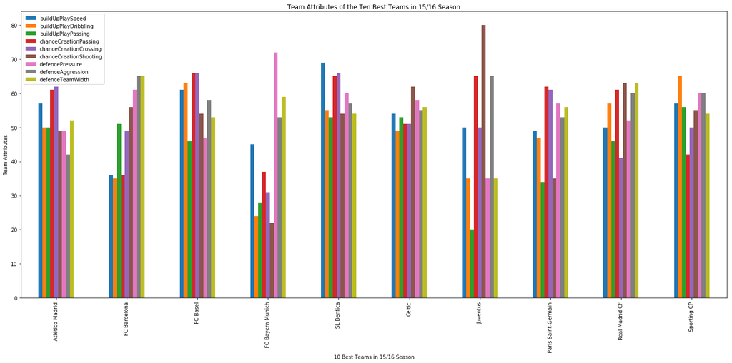

```python
# visualize the team attributes of teams with most victories in 2015/2016
fig, ax = plt.subplots(figsize=(20, 10))

# create a new bar char
ax = best_team_attributes.plot.bar(ax=ax)

ax.set_title('Team Attributes of the Ten Best Teams in 15/16 Season')
ax.set_xlabel("10 Best Teams in 15/16 Season")
ax.set_xticklabels(best_team_attributes['team_long_name'], rotation=90)
ax.set_ylabel('Team Attributes')

plt.tight_layout()
```

**Different teams played in different styles, so it's hard to say which team attributes are the best. Anyway, here are some conclusions I come up with to answer question 3:**

- **Teams with most victories in 15/16 season are Paris Saint-Germain(30), Juventus(29), FC Barcelona(29), SL Benfica(29), FC Bayern Munich(28), Atlético Madrid(28), Real Madrid CF(28), Sporting CP(27), Celtic(26), FC Basel(26).**
- **If we take Paris Saint-Germain in 15/16 as a specific example, the most important team attributes are change creation pass and change creation crossing. However, it does not imply this tactic applys to all the teams in different league.**
- **Other examples include: For Barcelona, they focused more on their defence aggression and defence team width. For Juventus, they focused more on change creation shooting. For SL Benfica, they focused more on build up play speed.**

### Research Question 4: What are the correlations between players attributes?

To successfully answer this question, we need to look at the **player attributes dataframes**, I first revisited its basic info.

```python
# look at player attributes head
df_player_attributes.head()
```

|  | id | player_fifa_api_id | player_api_id | date | overall_rating | potential | preferred_foot | attacking_work_rate | defensive_work_rate | crossing | ... | vision | penalties | marking | standing_tackle | sliding_tackle | gk_diving | gk_handling | gk_kicking | gk_positioning | gk_reflexes |
| --- | --- | --- | --- | --- | --- | --- | --- | --- | --- | --- | --- | --- | --- | --- | --- | --- | --- | --- | --- | --- | --- |
| 0 | 1 | 218353 | 505942 | 2016-02-18 | 67.0 | 71.0 | right | medium | medium | 49.0 | ... | 54.0 | 48.0 | 65.0 | 69.0 | 69.0 | 6.0 | 11.0 | 10.0 | 8.0 | 8.0 |
| 1 | 2 | 218353 | 505942 | 2015-11-19 | 67.0 | 71.0 | right | medium | medium | 49.0 | ... | 54.0 | 48.0 | 65.0 | 69.0 | 69.0 | 6.0 | 11.0 | 10.0 | 8.0 | 8.0 |
| 2 | 3 | 218353 | 505942 | 2015-09-21 | 62.0 | 66.0 | right | medium | medium | 49.0 | ... | 54.0 | 48.0 | 65.0 | 66.0 | 69.0 | 6.0 | 11.0 | 10.0 | 8.0 | 8.0 |
| 3 | 4 | 218353 | 505942 | 2015-03-20 | 61.0 | 65.0 | right | medium | medium | 48.0 | ... | 53.0 | 47.0 | 62.0 | 63.0 | 66.0 | 5.0 | 10.0 | 9.0 | 7.0 | 7.0 |
| 4 | 5 | 218353 | 505942 | 2007-02-22 | 61.0 | 65.0 | right | medium | medium | 48.0 | ... | 53.0 | 47.0 | 62.0 | 63.0 | 66.0 | 5.0 | 10.0 | 9.0 | 7.0 | 7.0 |

5 rows × 42 columns

```python
# look at player attributes info
df_player_attributes.info()
```

```
<class 'pandas.core.frame.DataFrame'>
RangeIndex: 183978 entries, 0 to 183977
Data columns (total 42 columns):
id                     183978 non-null int64
player_fifa_api_id     183978 non-null int64
player_api_id          183978 non-null int64
date                   183978 non-null datetime64[ns]
overall_rating         183142 non-null float64
potential              183142 non-null float64
preferred_foot         183142 non-null object
attacking_work_rate    180748 non-null object
defensive_work_rate    183142 non-null object
crossing               183142 non-null float64
finishing              183142 non-null float64
heading_accuracy       183142 non-null float64
short_passing          183142 non-null float64
volleys                181265 non-null float64
dribbling              183142 non-null float64
curve                  181265 non-null float64
free_kick_accuracy     183142 non-null float64
long_passing           183142 non-null float64
ball_control           183142 non-null float64
acceleration           183142 non-null float64
sprint_speed           183142 non-null float64
agility                181265 non-null float64
reactions              183142 non-null float64
balance                181265 non-null float64
shot_power             183142 non-null float64
jumping                181265 non-null float64
stamina                183142 non-null float64
strength               183142 non-null float64
long_shots             183142 non-null float64
aggression             183142 non-null float64
interceptions          183142 non-null float64
positioning            183142 non-null float64
vision                 181265 non-null float64
penalties              183142 non-null float64
marking                183142 non-null float64
standing_tackle        183142 non-null float64
sliding_tackle         181265 non-null float64
gk_diving              183142 non-null float64
gk_handling            183142 non-null float64
gk_kicking             183142 non-null float64
gk_positioning         183142 non-null float64
gk_reflexes            183142 non-null float64
dtypes: datetime64[ns](1), float64(35), int64(3), object(3)
memory usage: 59.0+ MB
```

To find the correlations between different columns of player attributes, I will plot a scatter matrix between all these variables. Before that, we need some data cleaning that includes:

- drop unnecessary columns
- fill in missing values with column average

```python
# make a copy of player attributes dataframe
df_player_attributes_copy = df_player_attributes.copy()

# drop unnecessary columns
df_player_attributes_copy = df_player_attributes_copy.drop(columns = ['id', 'player_fifa_api_id', 'player_api_id', 'date', 'preferred_foot', 'attacking_work_rate', 'defensive_work_rate'])

# fill in NaN values using the average values in that column
df_player_attributes_copy.fillna(df_player_attributes_copy.mean(), inplace=True)

df_player_attributes_copy.head()
```

|  | overall_rating | potential | crossing | finishing | heading_accuracy | short_passing | volleys | dribbling | curve | free_kick_accuracy | ... | vision | penalties | marking | standing_tackle | sliding_tackle | gk_diving | gk_handling | gk_kicking | gk_positioning | gk_reflexes |
| --- | --- | --- | --- | --- | --- | --- | --- | --- | --- | --- | --- | --- | --- | --- | --- | --- | --- | --- | --- | --- | --- |
| 0 | 67.0 | 71.0 | 49.0 | 44.0 | 71.0 | 61.0 | 44.0 | 51.0 | 45.0 | 39.0 | ... | 54.0 | 48.0 | 65.0 | 69.0 | 69.0 | 6.0 | 11.0 | 10.0 | 8.0 | 8.0 |
| 1 | 67.0 | 71.0 | 49.0 | 44.0 | 71.0 | 61.0 | 44.0 | 51.0 | 45.0 | 39.0 | ... | 54.0 | 48.0 | 65.0 | 69.0 | 69.0 | 6.0 | 11.0 | 10.0 | 8.0 | 8.0 |
| 2 | 62.0 | 66.0 | 49.0 | 44.0 | 71.0 | 61.0 | 44.0 | 51.0 | 45.0 | 39.0 | ... | 54.0 | 48.0 | 65.0 | 66.0 | 69.0 | 6.0 | 11.0 | 10.0 | 8.0 | 8.0 |
| 3 | 61.0 | 65.0 | 48.0 | 43.0 | 70.0 | 60.0 | 43.0 | 50.0 | 44.0 | 38.0 | ... | 53.0 | 47.0 | 62.0 | 63.0 | 66.0 | 5.0 | 10.0 | 9.0 | 7.0 | 7.0 |
| 4 | 61.0 | 65.0 | 48.0 | 43.0 | 70.0 | 60.0 | 43.0 | 50.0 | 44.0 | 38.0 | ... | 53.0 | 47.0 | 62.0 | 63.0 | 66.0 | 5.0 | 10.0 | 9.0 | 7.0 | 7.0 |

5 rows × 35 columns

Now we can proceed and plot the scatter matrix. I only picked up three features which I will include in my plot: **overall_rating, potential and vision** (It takes my laptop forever to plot for all the columns), you can add more features as you like :)

```
array([[<matplotlib.axes._subplots.AxesSubplot object at 0x00000207D19445F8>,
      dtype=object)
```

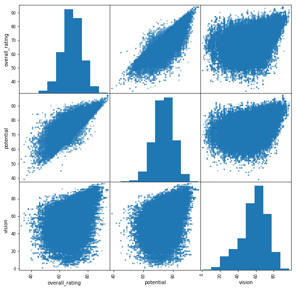

```python
# select features and plot the scatter matrix
features = ['overall_rating','potential', 'vision']
pd.plotting.scatter_matrix(df_player_attributes_copy[features], figsize=(10,10))
```

As seen from the plot above, there is a visiable correlation between a player's **overall_rating and potential**, we can do a linear regression on these two varlables.

```python
# linear regression on player's overall_rating and potential

regression_model = LinearRegression()

x = df_player_attributes_copy[['overall_rating']]
y = df_player_attributes_copy[['potential']]

# fit the data
regression_model.fit(x, y)

# predict the values with the x data to get the trend line
df_player_attributes_copy["trend_rating_potential"] = regression_model.predict(x)
```

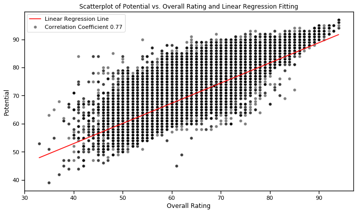

```python
# calculate the correlation between overall_rating and potential
corr = np.round(df_player_attributes_copy['overall_rating'].corr(df_player_attributes_copy['potential']), decimals=2)

# visualize the trend line
with sns.plotting_context("notebook"):
    # create a matplotlib figure
    fig, ax = plt.subplots(figsize = (10,6))

    # plot the scatterplot of player overall_rating and potential
    sns.scatterplot(x = "overall_rating", y = "potential", data = df_player_attributes_copy, label="Correlation Coefficient {}".format(corr), alpha = 0.5,
                 color = "k", lw = 2)
    # plot the trend line
    sns.lineplot(x = "overall_rating", y = "trend_rating_potential", data = df_player_attributes_copy, label = "Linear Regression Line", color = "r")
    # set the title, legend, x & y labels
    ax.set_title('Scatterplot of Potential vs. Overall Rating and Linear Regression Fitting')
    ax.legend(loc='best')
    ax.set_xlabel('Overall Rating')
    ax.set_ylabel('Potential')

    plt.tight_layout()
    plt.show()
```

**Here are some conclusions for question 4:**

- **I looked at the correlations between player attributes, in particular, the players overall rating, vision and potential.**
- **In general, a player's overall_rating is positively correlated with his/her potential, with a correlation coefficient of 0.77 (highly correlated), which indicates if a player has a higher potential, it's more likely for him/her to obtain a higher rating.**

### Research Question 5: What is the home team advantage in a soccer match?

To answer this question, we can use the **match_copy dataframe** and look at whether the winner of a match is the home team or away team.

```python
# recheck the match_copy dataframe
df_match_copy.head()
```

|  | id | country_id | league_id | season | date | match_api_id | home_team_goal | away_team_goal | home_team_name | away_team_name | winner |
| --- | --- | --- | --- | --- | --- | --- | --- | --- | --- | --- | --- |
| 0 | 1 | 1 | 1 | 2008/2009 | 2008-08-17 | 492473 | 1 | 1 | KRC Genk | Beerschot AC | Draw |
| 1 | 29 | 1 | 1 | 2008/2009 | 2008-11-15 | 492583 | 1 | 1 | KRC Genk | KSV Roeselare | Draw |
| 2 | 47 | 1 | 1 | 2008/2009 | 2008-11-29 | 492651 | 3 | 2 | KRC Genk | KSV Cercle Brugge | KRC Genk |
| 3 | 65 | 1 | 1 | 2008/2009 | 2008-12-13 | 492713 | 1 | 0 | KRC Genk | Sporting Charleroi | KRC Genk |
| 4 | 94 | 1 | 1 | 2008/2009 | 2009-01-24 | 492805 | 2 | 0 | KRC Genk | RAEC Mons | KRC Genk |

After checking the match_copy dataframe we created before, I realize it would be easier if we have an extra column, that uses **'home', 'away' or 'draw'** to indicate which team won, instead of using the names of the winning teams (in which case we will need to do an extra step and check whether the winner is the home or away team). I decided to create another column named **'home_win_or_away'** to store the information I need.

```python
# define a function to generate the winner info: 'home', 'away' or 'draw'
def home_win_or_away(column):
    home_goal, away_goal = column[0], column[1]
    home_team_name, away_team_name = column[2], column[3]

    if home_goal > away_goal:
        return 'Home'
    elif home_goal < away_goal:
        return 'Away'
    else:
        return 'Draw'

# add to the match_copy dataframe
df_match_copy['home_win_or_away'] = df_match_copy[['home_team_goal', 'away_team_goal', 'home_team_name', 'away_team_name']].apply(home_win_or_away, axis=1)
```

```python
# print the first five lines
df_match_copy.head()
```

|  | id | country_id | league_id | season | date | match_api_id | home_team_goal | away_team_goal | home_team_name | away_team_name | winner | home_win_or_away |
| --- | --- | --- | --- | --- | --- | --- | --- | --- | --- | --- | --- | --- |
| 0 | 1 | 1 | 1 | 2008/2009 | 2008-08-17 | 492473 | 1 | 1 | KRC Genk | Beerschot AC | Draw | Draw |
| 1 | 29 | 1 | 1 | 2008/2009 | 2008-11-15 | 492583 | 1 | 1 | KRC Genk | KSV Roeselare | Draw | Draw |
| 2 | 47 | 1 | 1 | 2008/2009 | 2008-11-29 | 492651 | 3 | 2 | KRC Genk | KSV Cercle Brugge | KRC Genk | Home |
| 3 | 65 | 1 | 1 | 2008/2009 | 2008-12-13 | 492713 | 1 | 0 | KRC Genk | Sporting Charleroi | KRC Genk | Home |
| 4 | 94 | 1 | 1 | 2008/2009 | 2009-01-24 | 492805 | 2 | 0 | KRC Genk | RAEC Mons | KRC Genk | Home |

From the last column of the output above, we have the infomation needed. Next, we can count on this column to see the frequencies of 'home' 'away' and 'draw' respectively.

```python
# calculate percentage of match results
home_win_ratio = df_match_copy.query('home_win_or_away == "Home"').shape[0] / df_match_copy.shape[0] * 100
away_win_ratio = df_match_copy.query('home_win_or_away == "Away"').shape[0] / df_match_copy.shape[0] * 100
draw_ratio = df_match_copy.query('home_win_or_away == "Draw"').shape[0] / df_match_copy.shape[0] * 100
```

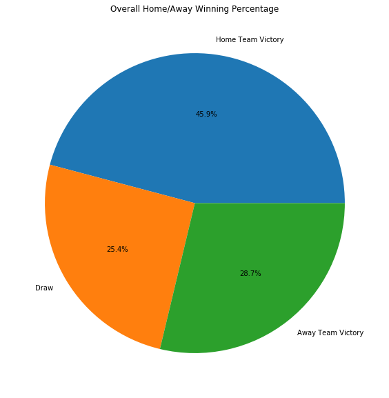

```python
# pie chart for result of matches in percentage
plt.figure(figsize=(10,10))
pie_labels = ['Home Team Victory', 'Draw', 'Away Team Victory']
plt.pie([home_win_ratio, draw_ratio, away_win_ratio], labels = pie_labels, autopct='%1.1f%%')
plt.title('Overall Home/Away Winning Percentage')
```

**To answer question 5:**

- **Home advantage exists in soccer games, with 45.9% of the matches resulting in home victory, 28.7% of the matches resulting in away victory, 25.4% of the matches ending in a draw.**

### Research Question 6: What are the best teams over the time period?

```python
# relook the match_copy dataframe
df_match_copy.head()
```

|  | id | country_id | league_id | season | date | match_api_id | home_team_goal | away_team_goal | home_team_name | away_team_name | winner | home_win_or_away |
| --- | --- | --- | --- | --- | --- | --- | --- | --- | --- | --- | --- | --- |
| 0 | 1 | 1 | 1 | 2008/2009 | 2008-08-17 | 492473 | 1 | 1 | KRC Genk | Beerschot AC | Draw | Draw |
| 1 | 29 | 1 | 1 | 2008/2009 | 2008-11-15 | 492583 | 1 | 1 | KRC Genk | KSV Roeselare | Draw | Draw |
| 2 | 47 | 1 | 1 | 2008/2009 | 2008-11-29 | 492651 | 3 | 2 | KRC Genk | KSV Cercle Brugge | KRC Genk | Home |
| 3 | 65 | 1 | 1 | 2008/2009 | 2008-12-13 | 492713 | 1 | 0 | KRC Genk | Sporting Charleroi | KRC Genk | Home |
| 4 | 94 | 1 | 1 | 2008/2009 | 2009-01-24 | 492805 | 2 | 0 | KRC Genk | RAEC Mons | KRC Genk | Home |

To answer this question, we can group by winners from the **match_copy dataframe**, and count how many times each winner appears in the table using count(), this will give us information on the total victories a team has over the period, which is a good measure of a team's success.

```python
# find the number of total victories of each team and sort by decending order
df_best_teams = df_match_copy.groupby('winner')['id'].count().sort_values(ascending=False)[1:21]
sorted_index = df_best_teams.index
df_best_teams
```

```
winner
FC Barcelona           234
Real Madrid CF         228
Celtic                 218
FC Bayern Munich       193
Manchester United      192
Juventus               189
SL Benfica             185
FC Porto               183
Ajax                   181
FC Basel               180
PSV                    178
Chelsea                176
Manchester City        175
Paris Saint-Germain    175
Arsenal                170
Atlético Madrid        167
Roma                   162
Borussia Dortmund      157
Inter                  154
Milan                  154
Name: id, dtype: int64
```

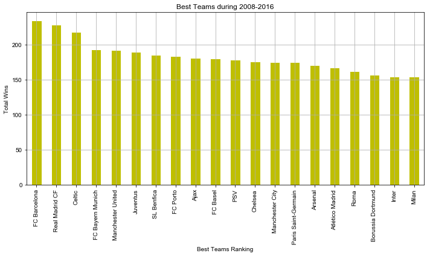

```python
# plot a bar chart to visualze the total vlctories of the top 20 teams
fig, ax = plt.subplots(figsize=(10, 6))
sns.set_style("whitegrid")

# create a new bar char
ax = df_best_teams.plot.bar(ax=ax, color = 'y')

ax.set_title('Best Teams during 2008-2016')
ax.set_xlabel("Best Teams Ranking")
ax.set_ylabel('Total Wins')

plt.tight_layout()
```

**To conclude for question 6:**

- **The best teams (with the most victories) over the time period are FC Barcelona (234 wins), Real Madrid CF (228), Celtic (218), FC Bayern Munich (193) and Manchester United (192).**

### Research Question 7: Who are the best players over the time period?

To evaluate who are the best players, we compare players' average overall rating over the years. I will use the **player and player attributes dataframes** and perform the following analysis:

- First, merge player and player_attributes dataframes, so we will have a player's name and rating in a single dataframe.
- Second, calculate the player's average rating during the time period, using his/her ratings from different seasons.
- Last, sort average ratings by decending order and pick up the top 20 players.

```python
# merge player and player_attribute dataframe for better analysis
df_player_all = df_player.merge(df_player_attributes, left_on='player_api_id', right_on='player_api_id', how='inner')
df_player_all.shape
```

```
(183978, 49)
```

```python
# check on the new dataframe player_all
df_player_all.head()
```

|  | id_x | player_api_id | player_name | player_fifa_api_id_x | birthday | height | weight | birthyear | id_y | player_fifa_api_id_y | ... | vision | penalties | marking | standing_tackle | sliding_tackle | gk_diving | gk_handling | gk_kicking | gk_positioning | gk_reflexes |
| --- | --- | --- | --- | --- | --- | --- | --- | --- | --- | --- | --- | --- | --- | --- | --- | --- | --- | --- | --- | --- | --- |
| 0 | 1 | 505942 | Aaron Appindangoye | 218353 | 1992-02-29 | 182.88 | 187 | 1992 | 1 | 218353 | ... | 54.0 | 48.0 | 65.0 | 69.0 | 69.0 | 6.0 | 11.0 | 10.0 | 8.0 | 8.0 |
| 1 | 1 | 505942 | Aaron Appindangoye | 218353 | 1992-02-29 | 182.88 | 187 | 1992 | 2 | 218353 | ... | 54.0 | 48.0 | 65.0 | 69.0 | 69.0 | 6.0 | 11.0 | 10.0 | 8.0 | 8.0 |
| 2 | 1 | 505942 | Aaron Appindangoye | 218353 | 1992-02-29 | 182.88 | 187 | 1992 | 3 | 218353 | ... | 54.0 | 48.0 | 65.0 | 66.0 | 69.0 | 6.0 | 11.0 | 10.0 | 8.0 | 8.0 |
| 3 | 1 | 505942 | Aaron Appindangoye | 218353 | 1992-02-29 | 182.88 | 187 | 1992 | 4 | 218353 | ... | 53.0 | 47.0 | 62.0 | 63.0 | 66.0 | 5.0 | 10.0 | 9.0 | 7.0 | 7.0 |
| 4 | 1 | 505942 | Aaron Appindangoye | 218353 | 1992-02-29 | 182.88 | 187 | 1992 | 5 | 218353 | ... | 53.0 | 47.0 | 62.0 | 63.0 | 66.0 | 5.0 | 10.0 | 9.0 | 7.0 | 7.0 |

5 rows × 49 columns

I realized there is no season info, so I added a column called 'season' based on date. **This will be useful to answer the next question.**

```python
# add season info based on date
def add_season(date):
    if date.month >= 7:
        return str(date.year) + "/" + str(date.year + 1)
    else:
        return str(date.year - 1) + "/" + str(date.year)

df_player_all['season'] = df_player_all['date'].apply(lambda t : add_season(t))
df_player_all.head()
```

|  | id_x | player_api_id | player_name | player_fifa_api_id_x | birthday | height | weight | birthyear | id_y | player_fifa_api_id_y | ... | penalties | marking | standing_tackle | sliding_tackle | gk_diving | gk_handling | gk_kicking | gk_positioning | gk_reflexes | season |
| --- | --- | --- | --- | --- | --- | --- | --- | --- | --- | --- | --- | --- | --- | --- | --- | --- | --- | --- | --- | --- | --- |
| 0 | 1 | 505942 | Aaron Appindangoye | 218353 | 1992-02-29 | 182.88 | 187 | 1992 | 1 | 218353 | ... | 48.0 | 65.0 | 69.0 | 69.0 | 6.0 | 11.0 | 10.0 | 8.0 | 8.0 | 2015/2016 |
| 1 | 1 | 505942 | Aaron Appindangoye | 218353 | 1992-02-29 | 182.88 | 187 | 1992 | 2 | 218353 | ... | 48.0 | 65.0 | 69.0 | 69.0 | 6.0 | 11.0 | 10.0 | 8.0 | 8.0 | 2015/2016 |
| 2 | 1 | 505942 | Aaron Appindangoye | 218353 | 1992-02-29 | 182.88 | 187 | 1992 | 3 | 218353 | ... | 48.0 | 65.0 | 66.0 | 69.0 | 6.0 | 11.0 | 10.0 | 8.0 | 8.0 | 2015/2016 |
| 3 | 1 | 505942 | Aaron Appindangoye | 218353 | 1992-02-29 | 182.88 | 187 | 1992 | 4 | 218353 | ... | 47.0 | 62.0 | 63.0 | 66.0 | 5.0 | 10.0 | 9.0 | 7.0 | 7.0 | 2014/2015 |
| 4 | 1 | 505942 | Aaron Appindangoye | 218353 | 1992-02-29 | 182.88 | 187 | 1992 | 5 | 218353 | ... | 47.0 | 62.0 | 63.0 | 66.0 | 5.0 | 10.0 | 9.0 | 7.0 | 7.0 | 2006/2007 |

5 rows × 50 columns

```python
# a function that returns a players average rating based on his player_id
def average_rating (player_id):
    season_rating = df_player_all.query('player_api_id ==  @player_id')['overall_rating'].mean()
    return season_rating
```

```python
# add a column in the player dataframe that records this player's average rating over the time period
df_player['average_rating'] = df_player['player_api_id'].apply(lambda p : average_rating(p))
df_player.sort_values('average_rating', ascending=False, inplace=True)
df_player.head()
```

|  | id | player_api_id | player_name | player_fifa_api_id | birthday | height | weight | birthyear | average_rating |
| --- | --- | --- | --- | --- | --- | --- | --- | --- | --- |
| 6169 | 6176 | 30981 | Lionel Messi | 158023 | 1987-06-24 | 170.18 | 159 | 1987 | 92.192308 |
| 1992 | 1995 | 30893 | Cristiano Ronaldo | 20801 | 1985-02-05 | 185.42 | 176 | 1985 | 91.280000 |
| 3510 | 3514 | 30924 | Franck Ribery | 156616 | 1983-04-07 | 170.18 | 159 | 1983 | 88.458333 |
| 739 | 742 | 30955 | Andres Iniesta | 41 | 1984-05-11 | 170.18 | 150 | 1984 | 88.320000 |
| 11041 | 11057 | 35724 | Zlatan Ibrahimovic | 41236 | 1981-10-03 | 195.58 | 209 | 1981 | 88.285714 |

```python
# get the rows that include the top 20 players by rating
df_top20_players = df_player.sort_values('average_rating', ascending=False)[:20]
df_top20_players
```

|  | id | player_api_id | player_name | player_fifa_api_id | birthday | height | weight | birthyear | average_rating |
| --- | --- | --- | --- | --- | --- | --- | --- | --- | --- |
| 6169 | 6176 | 30981 | Lionel Messi | 158023 | 1987-06-24 | 170.18 | 159 | 1987 | 92.192308 |
| 1992 | 1995 | 30893 | Cristiano Ronaldo | 20801 | 1985-02-05 | 185.42 | 176 | 1985 | 91.280000 |
| 3510 | 3514 | 30924 | Franck Ribery | 156616 | 1983-04-07 | 170.18 | 159 | 1983 | 88.458333 |
| 739 | 742 | 30955 | Andres Iniesta | 41 | 1984-05-11 | 170.18 | 150 | 1984 | 88.320000 |
| 11041 | 11057 | 35724 | Zlatan Ibrahimovic | 41236 | 1981-10-03 | 195.58 | 209 | 1981 | 88.285714 |
| 948 | 951 | 30834 | Arjen Robben | 9014 | 1984-01-23 | 180.34 | 176 | 1984 | 87.840000 |
| 10845 | 10861 | 39854 | Xavi Hernandez | 10535 | 1980-01-25 | 170.18 | 148 | 1980 | 87.636364 |
| 10733 | 10749 | 30829 | Wayne Rooney | 54050 | 1985-10-24 | 175.26 | 183 | 1985 | 87.222222 |
| 4362 | 4366 | 30657 | Iker Casillas | 5479 | 1981-05-20 | 185.42 | 185 | 1981 | 86.954545 |
| 8587 | 8601 | 30894 | Philipp Lahm | 121939 | 1983-11-11 | 170.18 | 146 | 1983 | 86.733333 |
| 2410 | 2413 | 37459 | David Silva | 168542 | 1986-01-08 | 170.18 | 148 | 1986 | 86.538462 |
| 9083 | 9097 | 30843 | Robin van Persie | 7826 | 1983-08-06 | 187.96 | 157 | 1983 | 86.473684 |
| 1642 | 1645 | 30613 | Cesc Fabregas | 162895 | 1987-05-04 | 175.26 | 163 | 1987 | 86.193548 |
| 9659 | 9674 | 37412 | Sergio Aguero | 153079 | 1988-06-02 | 172.72 | 163 | 1988 | 86.114286 |
| 1527 | 1530 | 30661 | Carles Puyol | 13038 | 1978-04-13 | 177.80 | 176 | 1978 | 85.888889 |
| 6546 | 6556 | 27299 | Manuel Neuer | 167495 | 1986-03-27 | 193.04 | 203 | 1986 | 85.862069 |
| 1578 | 1581 | 38817 | Carlos Tevez | 143001 | 1984-02-05 | 172.72 | 157 | 1984 | 85.789474 |
| 9684 | 9699 | 30962 | Sergio Ramos | 155862 | 1986-03-30 | 182.88 | 165 | 1986 | 85.789474 |
| 3822 | 3826 | 30717 | Gianluigi Buffon | 1179 | 1978-01-28 | 193.04 | 201 | 1978 | 85.774194 |
| 1148 | 1151 | 30872 | Bastian Schweinsteiger | 121944 | 1984-08-01 | 182.88 | 174 | 1984 | 85.653846 |

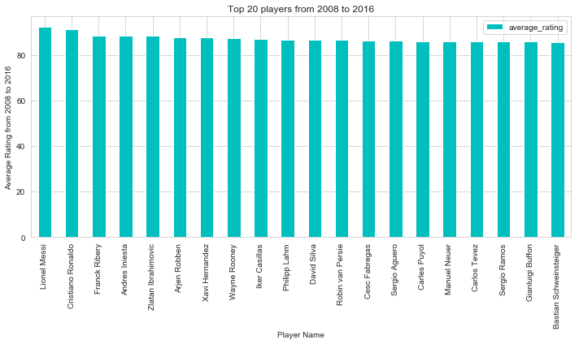

```python
# visualize who are the top 20 players
ax = df_top20_players.plot.bar(x='player_name', y='average_rating', color = 'c', figsize=(10,6))

ax.set_title('Top 20 players from 2008 to 2016')
plt.ylabel("Average Rating from 2008 to 2016")
ax.set_xlabel('Player Name')

plt.tight_layout()
```

**To answer question 7:**

- **The best player over the time period is Lionel Messi, with an average rating of 92.19.**
- **Top 20 players by average ratings are: Lionel Messi, Cristiano Ronaldo, Franck Ribery, Andres Iniesta, Zlatan Ibrahimovic, Arjen Robben, Xavi Hernandez, Wayne Rooney, Iker Casillas, Philipp Lahm, David Silva, Robin van Persie, Cesc Fabregas, Sergio Aguero, Carles Puyol, Manuel Neuer, Carlos Tevez, Sergio Ramos, Gianluigi Buffon and Bastian Schweinsteiger.**

### Research Question 8: Who are the players that improved most over the time period?

To answer this question, the change of a player's overall rating over the time period will be examined, the most improved player is the one that has the most points increased in his/her overall rating. (This is why I added the season info into the **player_all dataframe** from the last question).

The **player_api_id, player_name, overall_rating, season** are the most important columns, and I will create a new dataframe **df_mip (mip: most improved player)** that only includes these columns.

```python
df_mip = df_player_all[['player_api_id', 'player_name', 'overall_rating', 'season']].copy()
df_mip.head()
```

|  | player_api_id | player_name | overall_rating | season |
| --- | --- | --- | --- | --- |
| 0 | 505942 | Aaron Appindangoye | 67.0 | 2015/2016 |
| 1 | 505942 | Aaron Appindangoye | 67.0 | 2015/2016 |
| 2 | 505942 | Aaron Appindangoye | 62.0 | 2015/2016 |
| 3 | 505942 | Aaron Appindangoye | 61.0 | 2014/2015 |
| 4 | 505942 | Aaron Appindangoye | 61.0 | 2006/2007 |

```python
# functions that measure the difference in overall ratings over the years
def diff_rating (player_id):
    season_rating = df_mip.query('player_api_id ==  @player_id').groupby('season')['overall_rating'].mean()
    return season_rating[-1] - season_rating[0]

def rating_list (player_id):
    season_rating = df_mip.query('player_api_id ==  @player_id').groupby('season')['overall_rating'].mean()
    return season_rating
```

```python
# add a column called improvement (total rating change) into the player dataframe
df_player['improvement'] = df_player['player_api_id'].apply(lambda p : diff_rating(p))
df_player.sort_values('improvement', ascending=False, inplace=True)
df_player.head()
```

|  | id | player_api_id | player_name | player_fifa_api_id | birthday | height | weight | birthyear | average_rating | improvement |
| --- | --- | --- | --- | --- | --- | --- | --- | --- | --- | --- |
| 6715 | 6725 | 129944 | Marco Reus | 188350 | 1989-05-31 | 180.34 | 165 | 1989 | 81.500000 | 42.000000 |
| 2835 | 2838 | 107417 | Eden Hazard | 183277 | 1991-01-07 | 172.72 | 163 | 1991 | 82.724138 | 37.666667 |
| 8915 | 8929 | 115591 | Ricardo Rodriguez | 193352 | 1992-08-25 | 180.34 | 170 | 1992 | 72.896552 | 37.666667 |
| 8696 | 8710 | 41433 | Radja Nainggolan | 178518 | 1988-05-04 | 175.26 | 143 | 1988 | 76.717391 | 37.000000 |
| 8178 | 8190 | 181297 | Oscar de Marcos | 190149 | 1989-04-14 | 180.34 | 168 | 1989 | 73.285714 | 37.000000 |

```python
# find the top 10 mot improved players, stored in top10_improvers
df_top10_improvers = df_player.sort_values('improvement', ascending=False)[:10]
df_top10_improvers
```

|  | id | player_api_id | player_name | player_fifa_api_id | birthday | height | weight | birthyear | average_rating | improvement |
| --- | --- | --- | --- | --- | --- | --- | --- | --- | --- | --- |
| 6715 | 6725 | 129944 | Marco Reus | 188350 | 1989-05-31 | 180.34 | 165 | 1989 | 81.500000 | 42.000000 |
| 8915 | 8929 | 115591 | Ricardo Rodriguez | 193352 | 1992-08-25 | 180.34 | 170 | 1992 | 72.896552 | 37.666667 |
| 2835 | 2838 | 107417 | Eden Hazard | 183277 | 1991-01-07 | 172.72 | 163 | 1991 | 82.724138 | 37.666667 |
| 8696 | 8710 | 41433 | Radja Nainggolan | 178518 | 1988-05-04 | 175.26 | 143 | 1988 | 76.717391 | 37.000000 |
| 8178 | 8190 | 181297 | Oscar de Marcos | 190149 | 1989-04-14 | 180.34 | 168 | 1989 | 73.285714 | 37.000000 |
| 1083 | 1086 | 46417 | Bakary Sako | 179613 | 1988-04-26 | 182.88 | 198 | 1988 | 70.658537 | 37.000000 |
| 5956 | 5963 | 93457 | Lamine Kone | 184082 | 1989-02-01 | 185.42 | 183 | 1989 | 65.117647 | 36.000000 |
| 3905 | 3909 | 35523 | Glenn Murray | 172937 | 1983-09-25 | 185.42 | 185 | 1983 | 66.384615 | 36.000000 |
| 3460 | 3464 | 41841 | Francesco Della Rocca | 178043 | 1987-09-14 | 182.88 | 161 | 1987 | 64.761905 | 36.000000 |
| 6088 | 6095 | 24235 | Leonardo Bonucci | 184344 | 1987-05-01 | 190.50 | 190 | 1987 | 77.431818 | 36.000000 |

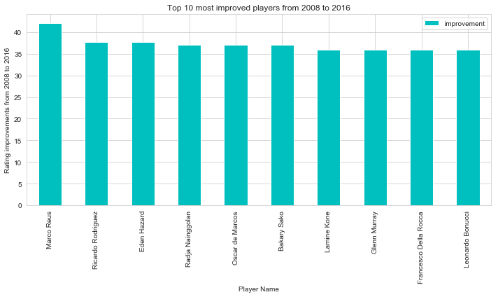

```python
# visualize the top 10 most improved players

ax = df_top10_improvers.plot.bar(x='player_name', y='improvement', color = 'c', figsize=(10,6))

ax.set_title('Top 10 most improved players from 2008 to 2016')

plt.ylabel("Rating improvements from 2008 to 2016")
ax.set_xlabel('Player Name')

plt.tight_layout()
```

```python
df_top10_improvers['player_name']
```

```
6715               Marco Reus
8915        Ricardo Rodriguez
2835              Eden Hazard
8696         Radja Nainggolan
8178          Oscar de Marcos
1083              Bakary Sako
5956              Lamine Kone
3905             Glenn Murray
3460    Francesco Della Rocca
6088         Leonardo Bonucci
Name: player_name, dtype: object
```

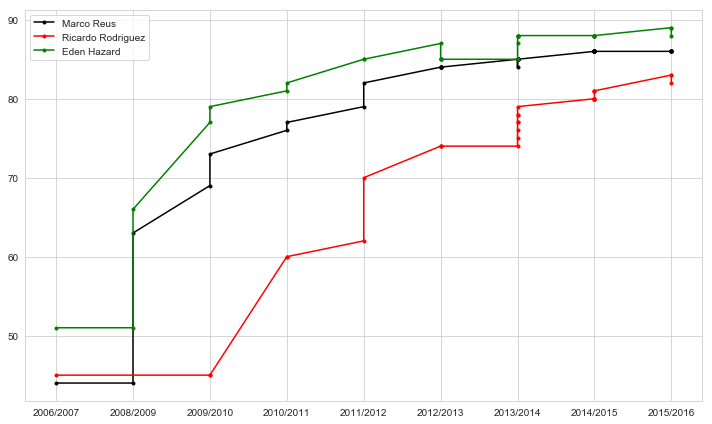

```python
# visualze the change in rating of Marco Reus, Ricardo Rodriguez and Eden Hazard
Marco_Reus = df_player_all.query('player_name == "Marco Reus"')
Ricardo_Rodriguez = df_player_all.query('player_name == "Ricardo Rodriguez"')
Eden_Hazard = df_player_all.query('player_name == "Eden Hazard"')
plt.figure(figsize=(10,6))
plt.plot(Marco_Reus['season'], Marco_Reus['overall_rating'], 'k.-', label = 'Marco Reus')
plt.plot(Ricardo_Rodriguez['season'], Ricardo_Rodriguez['overall_rating'], 'r.-', label = 'Ricardo Rodriguez')
plt.plot(Eden_Hazard['season'], Eden_Hazard['overall_rating'], 'g.-', label = 'Eden Hazard')
plt.legend()
plt.gca().invert_xaxis()
plt.tight_layout()
```

**For the last question:**

- **The most improved player is Marco Reus, who has a 42-point increase in his rating. The 2nd and 3rd place goes to Ricardo Rodriguez and Eden Hazard.**

## Conclusions

Before I make any conclusions on my analysis on the Kaggle soccer database, I will first talk about its **limitations**.

- The match dataframe contains lots of missing values. When I did the analysis, I simply dropped columns with missing values because these rows are also the rows that I'm not interested in. If further analysis is needed on those column, filling missing values or other equivalent methods are necessary.
- In the player attributes dataframe, I analyzed the scatter matrix between different variables. In order to deal with the missing values, I used column average to fill in those cells. If from other resources these values become available, that dataframe will need to be updated.
- During the exploration of the relation between different player attributes, I only chose three features because the time it takes to plot all scatter matrix is too long and causes my computer to crush down. if a complete picture is needed, one would include all the features in the corresponding code cell.

To conclude, I have analyzed the **Kaggle European Soccer Database** using **sql, numpy, pandas, matplotlib, LinearRegression**, etc.

Here is a summary of the answers to the listed questions:

- **What are the distributions of players age, height and weight?**
  - In terms of birthyear, the oldest player was born in 1967 and the youngest player was born in 1999. The average birthyear of a player is 1986, with most of the players (75%) born after 1983.
  - In terms of players' height, the tallest player is 208.28cm and the shorest player is 157.48cm. The average height of a player is 181.87cm.
  - In terms of players' weight, the heaviest player is 243.00lb and the lightest player is 117.00lb. The average weight of a player is 168.38lb.
  - The birthyear, height and weight are approximately normally distributed.
- **What teams improved the most over the time period?**
  - In terms of home goal increase per game, Paris Saint-Germain, SL Benfica and Cracovia are the teams that improved most.
  - In terms of away goal increase per game, Sporting CP, Paris Saint-Germain and Rio Ave FC are the teams that improved most.
  - Overall, Paris Saint-Germain is the team that improved the most over the time period, with home goals increased by ~1.6 per game and away goals increased by ~1.2 per game.
- **Which players had the most penalties?**
  - Alessio Cerci (4314), Mario Balotelli (4120) and Claudio Marchisio (3984) are the players with most penalties.
- **What team attributes lead to the most victories?**
  - Teams with most victories in 15/16 season are Paris Saint-Germain(30), Juventus(29), FC Barcelona(29), SL Benfica(29), FC Bayern Munich(28), Atlético Madrid(28), Real Madrid CF(28), Sporting CP(27), Celtic(26), FC Basel(26).
  - If we take Paris Saint-Germain in 15/16 as a specific example, the most important team attributes are change creation pass and change creation crossing. However, it does not imply this tactic applys to all the teams in different league.
  - Other examples include: For Barcelona, they focused more on their defence aggression and defence team width. For Juventus, they focused more on change creation shooting. For SL Benfica, they focused more on build up play speed.
- **What are the correlations between players attributes?**
  - I looked at the correlations between player attributes, in particular, the players overall rating, vision and potential.
  - In general, a player's overall_rating is positively correlated with his/her potential, with a correlation coefficient of 0.77 (highly correlated), which indicates if a player has a higher potential, it's more likely for him/her to obtain a higher rating.
- **What is the home team advantage in a soccer match?**
  - Home advantage exists in soccer games, with 45.9% of the matches resulting in home victory, 28.7% of the matches resulting in away victory, 25.4% of the matches ending in a draw.
- **What are the best teams over the time period?**
  - The best teams (with the most victories) over the time period are FC Barcelona (234 wins), Real Madrid CF (228), Celtic (218), FC Bayern Munich (193) and Manchester United (192).
- **Who are the best players over the time period?**
  - The best player over the time period is Lionel Messi, with an average rating of 92.19.
  - Top 20 players by average ratings are: Lionel Messi, Cristiano Ronaldo, Franck Ribery, Andres Iniesta, Zlatan Ibrahimovic, Arjen Robben, Xavi Hernandez, Wayne Rooney, Iker Casillas, Philipp Lahm, David Silva, Robin van Persie, Cesc Fabregas, Sergio Aguero, Carles Puyol, Manuel Neuer, Carlos Tevez, Sergio Ramos, Gianluigi Buffon and Bastian Schweinsteiger.
- **Who are the players that improved most over the time period?**
  - The most improved player is Marco Reus, who has a 42-point increase in his rating. The 2nd and 3rd place goes to Ricardo Rodriguez and Eden Hazard.